# Seurat to Single Cell Experiment

Bioconductor Group at CZI

April 2018

# 1 Introduction

The goal is to create a bridge between Seurat and Bioconductor Single Cell Experiment Packages

# 2 Data / Starting Point

The starting point is the Seurat Tutorial

http://satijalab.org/seurat/get_started.html

# 3 First, we make sure we can run the code from the Tutorial: https://www.dropbox.com/s/tn7ql6mjmcubhpt/pbmc3k_tutorial.Rmd?dl=1

## 3.1 Load libraries

```r
library(Seurat)
library(dplyr)
```

## 3.2 Load Data

```r
pbmc.data <- Read10X(data.dir = "filtered_gene_bc_matrices/hg19/")
pbmc <- CreateSeuratObject(raw.data = pbmc.data, min.cells = 3, min.genes = 200, project = "10X_PBMC")
pbmc
```

```
## An object of class seurat in project 10X_PBMC
##  13714 genes across 2700 samples.
```

## 3.3 Enrich/Filter/Normalize Data

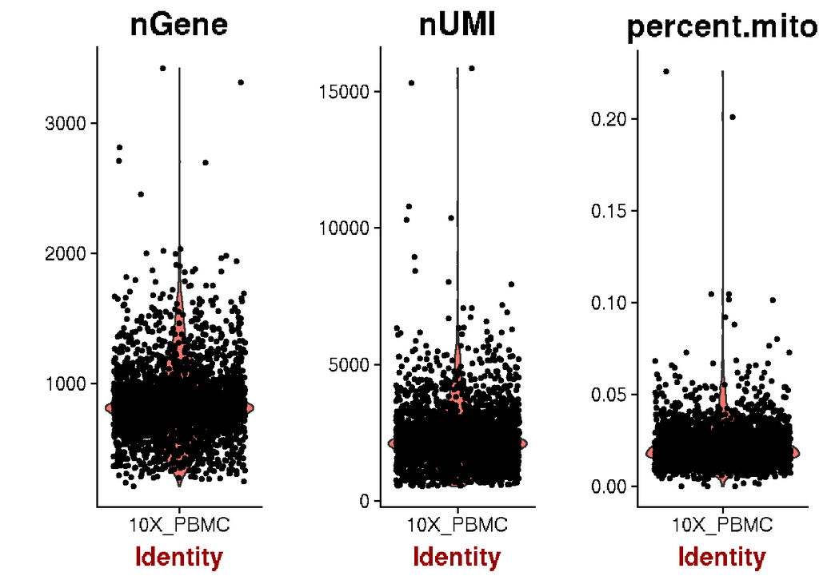

```r
mito.genes <- grep(pattern = "^MT-", x = rownames(x = pbmc@data), value = TRUE)
percent.mito <- Matrix::colSums(pbmc@raw.data[mito.genes, ]) / Matrix::colSums(pbmc@raw.data)
pbmc <- AddMetaData(object = pbmc, metadata = percent.mito, col.name = "percent.mito")
VlnPlot(object = pbmc, features.plot = c("nGene", "nUMI", "percent.mito"), nCol = 3)
```

```r
pbmc <- FilterCells(object = pbmc, subset.names = c("nGene", "percent.mito"), low.thresholds = c(200, -Inf), high.thresholds = c(2500, 0.05))
pbmc <- NormalizeData(object = pbmc, normalization.method = "LogNormalize", scale.factor = 1e4)
pbmc <- FindVariableGenes(object = pbmc, mean.function = ExpMean, dispersion.function = LogVMR, x.low.cutoff = 0.0125, x.high.cutoff = 3, y.cutoff = 0.5)
```

[figure not shown]

```r
pbmc <- ScaleData(object = pbmc, vars.to.regress = c("nUMI", "percent.mito"))
pbmc <- RunPCA(object = pbmc, pc.genes = pbmc@var.genes, do.print = TRUE, pcs.print = 1:5, genes.print = 5)
pbmc <- JackStraw(object = pbmc, num.replicate = 100, display.progress = FALSE)
pbmc <- FindClusters(object = pbmc, reduction.type = "pca", dims.use = 1:10, resolution = 0.6, print.output = 0, save.SNN = TRUE)
pbmc <- RunTSNE(object = pbmc, dims.use = 1:10)
pbmc
```

[output not shown]

## 3.4 Verify data

```r
pbmc
```

```
## An object of class seurat in project 10X_PBMC
##  13714 genes across 2638 samples.
```

```r
cluster1.markers <- FindMarkers(object = pbmc, ident.1 = 1, min.pct = 0.25)
print(x = head(x = cluster1.markers, n = 5))
```

```
##               p_val avg_logFC pct.1 pct.2     p_val_adj
## S100A9  0.00000e+00  3.830954 0.996 0.216  0.000000e+00
## S100A8  0.00000e+00  3.786963 0.973 0.122  0.000000e+00
## LGALS2  0.00000e+00  2.639056 0.908 0.060  0.000000e+00
## FCN1    0.00000e+00  2.367232 0.954 0.151  0.000000e+00
## CD14   5.05283e-289  1.947447 0.662 0.029 6.929451e-285
```

# 4 Seurat Class - from Package Manual

## 4.1 Description

The Seurat object is the center of each single cell analysis. It stores all information associated with the dataset, including data, annotations, analyes, etc. All that is needed to construct a Seurat object is an expression matrix (rows are genes, columns are cells), which should be log-scale

## 4.2 Details

Each Seurat object has a number of slots which store information. Key slots to access are listed below.

## 4.3 Slots

- raw.data The raw project data
- data The normalized expression matrix (log-scale)
- scale.data scaled (default is z-scoring each gene) expression matrix; used for dimmensional reduction
- and heatmap visualization
- var.genes Vector of genes exhibiting high variance across single cells
- is.expr Expression threshold to determine if a gene is expressed (0 by default)
- ident THe ’identity class’ for each cell
- meta.data Contains meta-information about each cell, starting with number of genes detected (nGene) and the original identity class (orig.ident); more information is added using AddMetaData
- project.name Name of hte project (for record keeping)
- dr List of stored dimmensional reductions; named by technique
- assay List of additional assays for multimodal analysis; named by technique
- hvg.info The output of the mean/variability analysis for all genes
- imputed Matrix of imputed gene scores
- cell.names Names of all single cells (column names of the expression matrix)
- cluster.tree List where the first element is a phylo object containing the phylogenetic tree relating different identity classes
- snn Spare matrix object representation of the SNN graph
- calc.params Named list to store all calculation-related parameter choices
- kmeans Stores output of gene-based clustering from DoKMeans
- spatial Stores internal data and calculations for spatial mapping of single cells
- misc Miscellaneous spot to store any data alongisde the object (for example, gene lists)
- version Version of package used in object creation

# 5 Single Cell Experiment class - from Manual

## 5.1 Description

A description of the SingleCellExperiment class for storing single-cell sequencing data.

## 5.2 Usage

SingleCellExperiment(…, reducedDims=SimpleList())

### 5.2.1 S4 method for signature ‘SingleCellExperiment’

colData(x, internal=FALSE)

### 5.2.2 S4 method for signature ‘SingleCellExperiment’

rowData(x, internal=FALSE)

## 5.3 Arguments

- … Arguments to pass to the SummarizedExperiment constructor.
- reducedDims A SimpleList object containing matrices of cell coordinates in reduced space.
- x A SingleCellExperiment object.
- internal Whether the information contained in the internal slots should be returned. See details.

## 5.4 Details

The SingleCellExperiment class inherits from the SummarizedExperiment class, with several additional slots:

- reducedDims: A SimpleList containing matrices of cell coordinates.
- int_elementMetadata: A DataFrame containing internal row metadata (for each genomic feature).
- int_colData: A DataFrame containing internal column metadata (for each cell).
- int_metadata: A list containing internal experiment metadata.
- The intended use of this class is the same as that for SummarizedExperiment instances. Rows should represent genomic features such as genes, while columns represent samples - in this case, single cells. Different quantifications (e.g., counts, CPMs, log-expression) can be stored simultaneously in the assays slot. Row and column metadata can be attached using rowData and colData, respectively.

The additional reducedDims slot allows storage of results from multiple dimensionality reduction methods, e.g., PCA or t-SNE. Each element of the SimpleList should be a matrix of coordinates for all cells from one reduction method. The number of rows of each matrix should be equal to the number of cells in the SingleCellExperiment object.

The internal metadata slots are not intended for external use. Please use the appropriate getter/setter functions instead, such as isSpike or sizeFactors. It may sometimes be useful to return both the visible and the internal colData in a single DataFrame. This can be achieved by using colData(x, internal=TRUE), which will return the stored colData along with the int_colData (currently the sizeFactors). Similarly, rowData(x, internal=TRUE) will return the stored rowData along with the int_rowData (currently the columns corresponding to isSpike). Warnings will be raised in the unlikely event of any name clashes.

# 6 Translational Grammer: Seurat to Single Cell Experiment

1. raw.data, scale.data, data, imputed, and assay list -> assays
2. pca, dr, kmeans, hvg.info, meta.data,snn -> reducedDims
3. var.genes -> reducedDims as a binary to preserve dims?
4. project.name, is.expr, calc.params -> metadata

# 7 Seurat to Single Cell experiment

```r
seurat2BC<-function(myseurat){
  require(SingleCellExperiment)
  arrayList=list()
  if(ncol(myseurat@raw.data)>0&ncol(myseurat@data)>0&ncol(myseurat@data)!=ncol(myseurat@raw.data)){
    warning("Raw Data is not the same size as Data. Raw Data is truncated")}
  if(nrow(myseurat@raw.data>0)){arrayList[["raw.data"]]=myseurat@raw.data[,colnames(myseurat@data),]}
  if(nrow(myseurat@scale.data>0)){arrayList[["scale.data"]]=myseurat@scale.data}
  if(nrow(myseurat@data>0)){arrayList[["data"]]=myseurat@data}
  if(nrow(myseurat@imputed>0)){arrayList[["imputed"]]=myseurat@imputed}

reducedList=lapply(myseurat@dr,function(x){x@cell.embeddings})

  sce <- SingleCellExperiment(
    assays=arrayList,
    reducedDims = SimpleList(reducedList),
    metadata=list(
      project.name=myseurat@project.name,is.expr=myseurat@is.expr,calc.params=myseurat@calc.params )
  )
return(sce)
}

mySC=seurat2BC(pbmc)
```

# 8 Seurat and SingleCellExperiment

## 8.1 Seurat

```r
pbmc
```

```
## An object of class seurat in project 10X_PBMC
##  13714 genes across 2638 samples.
```

## 8.2 SingleCellExperiment

```r
mySC
```

```
## class: SingleCellExperiment
## dim: 13714 2638
## metadata(3): project.name is.expr calc.params
## assays(3): raw.data scale.data data
## rownames(13714): AL627309.1 AP006222.2 ... PNRC2.1 SRSF10.1
## rowData names(0):
## colnames(2638): AAACATACAACCAC AAACATTGAGCTAC ... TTTGCATGAGAGGC TTTGCATGCCTCAC
## colData names(0):
## reducedDimNames(2): pca tsne
## spikeNames(0):
```

# 9 Caveats

Do we need all of the slots from the dr objects? There are dimension isuses if we do.

```r
str(pbmc@dr[[1]])
```

```
## Formal class 'dim.reduction' [package "Seurat"] with 7 slots
##   ..@ cell.embeddings   : num [1:2638, 1:20] 5.57 7.22 2.71 -10.13 -1.1 ...
##   .. ..- attr(*, "dimnames")=List of 2
##   .. .. ..$ : chr [1:2638] "AAACATACAACCAC" "AAACATTGAGCTAC" "AAACATTGATCAGC" "AAACCGTGCTTCCG" ...
##   .. .. ..$ : chr [1:20] "PC1" "PC2" "PC3" "PC4" ...
##   ..@ gene.loadings     : num [1:1838, 1:20] 0.02601 0.00828 0.00331 -0.01065 -0.01372 ...
##   .. ..- attr(*, "dimnames")=List of 2
##   .. .. ..$ : chr [1:1838] "TNFRSF4" "CPSF3L" "ATAD3C" "C1orf86" ...
##   .. .. ..$ : chr [1:20] "PC1" "PC2" "PC3" "PC4" ...
##   ..@ gene.loadings.full: num[0 , 0 ]
##   ..@ sdev              : num [1:20] 5.67 4.33 3.95 3.64 2.19 ...
##   ..@ key               : chr "PC"
##   ..@ jackstraw         :Formal class 'jackstraw.data' [package "Seurat"] with 3 slots
##   .. .. ..@ emperical.p.value     : num [1:1838, 1:20] 0 0.01444 0.30111 0.00167 0 ...
##   .. .. .. ..- attr(*, "dimnames")=List of 2
##   .. .. .. .. ..$ : chr [1:1838] "TNFRSF4" "CPSF3L" "ATAD3C" "C1orf86" ...
##   .. .. .. .. ..$ : chr [1:20] "PC1" "PC2" "PC3" "PC4" ...
##   .. .. ..@ fake.pc.scores        : num [1:1800, 1:20] 0.001101 -0.000518 0.003293 0.002227 -0.002466 ...
##   .. .. ..@ emperical.p.value.full: logi [1, 1] NA
##   ..@ misc              : NULL
```

# 10 SessionInfo

```r
library(devtools)
```

[output not shown]

[output cut: 109 more lines]

[output not shown]